# Sentiment Analysis

Kirsten Ronning

2/26/2021

# Introduction

Throughout CPP 527, we have focused on numerous data science functions that are utilizable in R. After learning multiple methods to manipulate and analyze text as data, including regular expressions and the **quanteda** package, I decided to further explore more packages in R that are helpful for text and sentiment analysis.

# Content Overview

This code-through will cover various text and sentiment analysis options in both the **quanteda** and **tidytext** packages. We will use the 2014 State of the Union Address that President Barack Obama delivered in order to analyze the words used most frequently, as well as the sentiments those words elicited.

Ensure that the following packages are installed:

```r
library( quanteda )
library( readtext )
library( dplyr )
library( stringr )
library( tidytext )
library( tidyverse )
library( textdata )
```

Upload the .txt file containing the 2014 State of the Union address.

```r
data <- readtext("https://raw.githubusercontent.com/datameister66/data/master/sou2014.txt")
data
```

| doc_id | text |
| --- | --- |
| sou2014.txt | "x"\n"1" "Today in America, a teacher spent extra time with a student who needed it, and did her part to lift Americas graduation rate to its highest level in more than three decades. An entrepreneur … |

# Quanteda Package

To begin, create a corpus out of the State of the Union document.

```r
sou_corpus <- corpus( data )
summary( sou_corpus )
```

|  | Text | Types | Tokens | Sentences |
| --- | --- | --- | --- | --- |
| 1 | sou2014.txt | 1918 | 7553 | 343 |

We can use tokens() to clean up the data.

```r
sou_corpus_edit <- tokens( sou_corpus, remove_numbers = TRUE, remove_punct = TRUE, remove_separators = TRUE, remove_symbols = TRUE )
```

From there, construct a document-feature matrix (dfm).

We then use the textplot_wordcloud function to create a word cloud featuring the most popular words used in his speech.

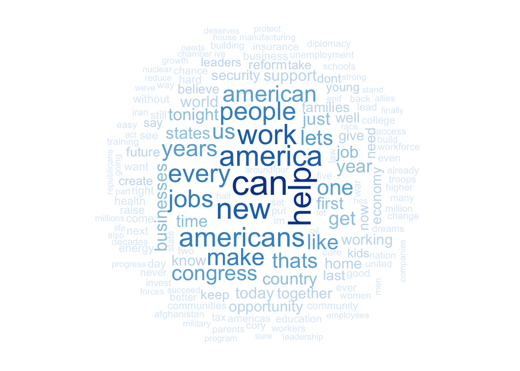

```r
sou_dfm <- dfm( sou_corpus_edit, remove = stopwords("english"), remove_punct = TRUE )

textplot_wordcloud( sou_dfm, min_count=5, color = RColorBrewer::brewer.pal( 8, "Blues" ))
```

While this word cloud is visually appealing, it does not necessarily give exact information regarding the frequency these words appear in the speech . We can use ggplot() to create a frequency chart representing the top words.

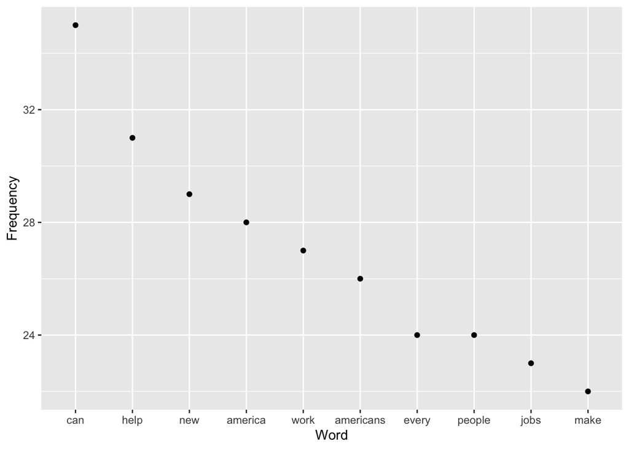

```r
sou_features <- topfeatures( sou_dfm, 10 )

top_features <- data.frame(
  list(
    term = names( sou_features ),
    frequency = unname( sou_features )
  )
)

top_features$term <- with( top_features, reorder( term, -frequency ))

ggplot( top_features ) + geom_point( aes( x=term, y=frequency )) + theme_replace() + labs( x = "Word", y = "Frequency" )
```

# Tidytext Package

Another important skill that CPP 527 covered is the importance of tidy data. The **tidytext** package not only provides ease in cleaning data, but it also features another level of text analysis: sentiment analysis.

Begin by tidying up the 2014 State of the Union Address. This will separate each line into a list of individual words.

```r
tidy_sou <- data %>%
  unnest_tokens( word, text )

tidy_sou
```

| doc_id | word |
| --- | --- |
| sou2014.txt | x |
| sou2014.txt | 1 |
| sou2014.txt | today |
| sou2014.txt | in |
| sou2014.txt | america |
| sou2014.txt | a |
| sou2014.txt | teacher |
| sou2014.txt | spent |
| sou2014.txt | extra |
| sou2014.txt | time |

[output cut: 6820 more lines]

From there, we can begin to perform sentiment analysis on our words.

**tidytext** uses three different dataset options for classifying sentiment. There is:

- AFINN
- bing
- nrc

*AFINN* rates each word with a score ranging on a scale from -5 (most negative) to 5 (most positive).

*bing* sorts each word into negative or positive.

*nrc* has a broader selection of negative and positive categories: anticipation, disgust, fear, joy, negative, positive, sadness, surprise, and trust.

Use *bing* to identify the positive words and count how many times they appear in the speech:

```r
positive <- get_sentiments( "bing" ) %>%
  filter( sentiment == "positive" )

tidy_sou %>%
  semi_join( positive) %>%
  count( word, sort = TRUE )
```

| word | n |
| --- | --- |
| work | 28 |
| like | 19 |
| support | 13 |
| well | 11 |
| reform | 10 |
| better | 8 |
| right | 8 |
| good | 7 |
| lead | 7 |
| easy | 6 |

[output cut: 110 more lines]

Now, identify and count the negative words:

```r
negative <- get_sentiments( "bing" ) %>%
  filter( sentiment == "negative" )

tidy_sou %>%
  semi_join( negative ) %>%
  count( word, sort = TRUE )
```

| word | n |
| --- | --- |
| hard | 9 |
| bomb | 3 |
| fear | 3 |
| inequality | 3 |
| poverty | 3 |
| sick | 3 |
| threats | 3 |
| broken | 2 |
| cold | 2 |
| crisis | 2 |

[output cut: 90 more lines]

Use ggplot() to visualize the frequency of positive words compared to negative words.

```r
bing <- get_sentiments( "bing" )

bing_word_counts <- tidy_sou %>%
  inner_join( bing) %>%
  count( word, sentiment, sort = TRUE )
bing_word_counts
```

| word | sentiment | n |
| --- | --- | --- |
| work | positive | 28 |
| like | positive | 19 |
| support | positive | 13 |
| well | positive | 11 |
| reform | positive | 10 |
| hard | negative | 9 |
| better | positive | 8 |
| right | positive | 8 |
| good | positive | 7 |
| lead | positive | 7 |

[output cut: 210 more lines]

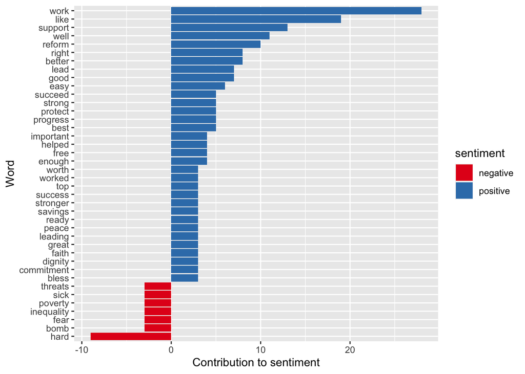

```r
bing_word_counts %>%
  filter( n > 2 ) %>%
  mutate (n = ifelse( sentiment == "negative", -n, n)) %>%
  mutate( word = reorder( word, n )) %>%
  ggplot( aes( word, n, fill = sentiment )) +
  geom_col() +
  coord_flip() +
  labs( x = "Word", y = "Contribution to sentiment" ) +
  scale_fill_brewer( palette="Set1" )
```

Take a look at how *nrc* classifies the words into more specific sentiments.

**Trust:**

```r
trust <- get_sentiments( "nrc" ) %>%
  filter( sentiment == "trust" )

tidy_sou %>%
  semi_join( trust ) %>%
  count( word, sort = TRUE )
```

| word | n |
| --- | --- |
| congress | 19 |
| economy | 11 |
| good | 7 |
| diplomacy | 6 |
| law | 6 |
| nation | 6 |
| united | 6 |
| finally | 5 |
| succeed | 5 |
| budget | 4 |

[output cut: 133 more lines]

**Anticipation:**

```r
anticipation <- get_sentiments( "nrc" ) %>%
  filter( sentiment == "anticipation" )

tidy_sou %>%
  semi_join( anticipation ) %>%
  count( word, sort = TRUE )
```

| word | n |
| --- | --- |
| time | 14 |
| opportunity | 12 |
| young | 9 |
| good | 7 |
| diplomacy | 6 |
| finally | 5 |
| long | 5 |
| progress | 5 |
| succeed | 5 |
| child | 4 |

[output cut: 72 more lines]

**Disgust:**

```r
disgust <- get_sentiments( "nrc" ) %>%
  filter( sentiment == "disgust" )

tidy_sou %>%
  semi_join( disgust ) %>%
  count( word, sort = TRUE )
```

| word | n |
| --- | --- |
| congress | 19 |
| finally | 5 |
| ill | 3 |
| john | 3 |
| pollution | 3 |
| poverty | 3 |
| sick | 3 |
| terrorist | 3 |
| remains | 2 |
| bacteria | 1 |

[output cut: 17 more lines]

We can use ggplot() to create a frequency table showing the *nrc* sentiments as well:

```r
nrc <- get_sentiments( "nrc" )

nrc_word_counts <- tidy_sou %>%
  inner_join( nrc) %>%
  count( word, sentiment, sort = TRUE )
nrc_word_counts
```

| word | sentiment | n |
| --- | --- | --- |
| congress | disgust | 19 |
| congress | trust | 19 |
| job | positive | 15 |
| time | anticipation | 14 |
| working | positive | 13 |
| opportunity | anticipation | 12 |
| opportunity | positive | 12 |
| economy | trust | 11 |
| reform | positive | 10 |
| create | joy | 9 |

[output cut: 892 more lines]

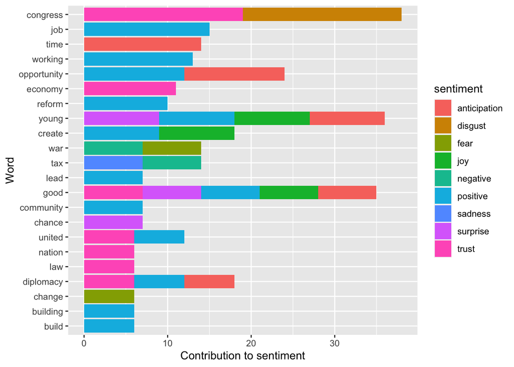

```r
nrc_word_counts %>%
  filter( n > 5 ) %>%
  mutate( word = reorder( word, n )) %>%
  ggplot( aes( word, n, fill = sentiment )) +
  geom_col() +
  coord_flip() +
  labs( x = "Word", y = "Contribution to sentiment" )
```

# Works Cited

This code references and cites the following sources:

- data. (2017). https://github.com/datameister66/data
- Introduction to tidytext. (2021). https://cran.r-project.org/web/packages/tidytext/vignettes/tidytext.html
- Quick Start Guide. (n.d.). https://quanteda.io/articles/pkgdown/quickstart.html
- Sentiment analysis with tidy data. (2020). https://www.tidytextmining.com/sentiment.html